# Coursera Machine Learning Final Project

mcm45

April 16, 2017

## Background

### Data

Using devices such as Jawbone Up, Nike FuelBand, and Fitbit it is now possible to collect a large amount of data about personal activity relatively inexpensively. These type of devices are part of the quantified self movement - a group of enthusiasts who take measurements about themselves regularly to improve their health, to find patterns in their behavior, or because they are tech geeks. One thing that people regularly do is quantify how much of a particular activity they do, but they rarely quantify how well they do it. More information is available from the website here: http://groupware.les.inf.puc-rio.br/har (see the section on the Weight Lifting Exercise Dataset).

### Goals

```r
library(AppliedPredictiveModeling)
```

```r
library(ggplot2)
library(lattice)
library(caret)
library(randomForest)
training <- read.csv("pml-training.csv")
testing <- read.csv("pml-testing.csv")
dim(training)
```

```
## [1] 19622   160
```

```r
dim(testing)
```

```
## [1]  20 160
```

## Partitioning and Understanding Data

This is a moderate size dataset so cross validation will be done by partitioning this training set.

```r
trainIndex = createDataPartition(training$classe,p=0.7,list=FALSE)
mytrain = training[trainIndex,]
mytest = training[-trainIndex,]
dim(mytrain)
```

```
## [1] 13737   160
```

```r
dim(mytest)
```

```
## [1] 5885  160
```

```r
#str(mytrain)
```

From looking at the str function results, it looks like the data come from four input sources: belt, dumbbell, forearm, and arm. There are several idenfitication variables (e.g. username) at the beginning of the dataset that won’t be needed as predictors. There are also several variables with mostly NAs and others (skew and kurtosis variables) that likely have limited variance.

## Cleaning

```r
#remove first 7 variables with username and other uninformative covariates
mytrain_rm <- mytrain[,8:160]
#remove variables with over 75% NAs
mytrain_rm <- mytrain_rm[,colSums(!is.na(mytrain_rm)) > nrow(mytrain_rm)*.75]
#remove variables with non-zero variance
nzv <- nearZeroVar(mytrain_rm, saveMetrics=T)
mytrain_rm <- mytrain_rm[,nzv$nzv==F]
train_short <- mytrain_rm
dim(train_short)
```

```
## [1] 13737    53
```

Repeat for test set.

```r
mytest_rm <- mytest[,8:160]
mytest_rm <- mytest_rm[,colSums(!is.na(mytest_rm)) > nrow(mytest_rm)*.90]
nzv <- nearZeroVar(mytest_rm, saveMetrics=T)
test_short <- mytest_rm[,nzv$nzv==F]
dim(test_short)
```

```
## [1] 5885   53
```

### Plotting Selected Features

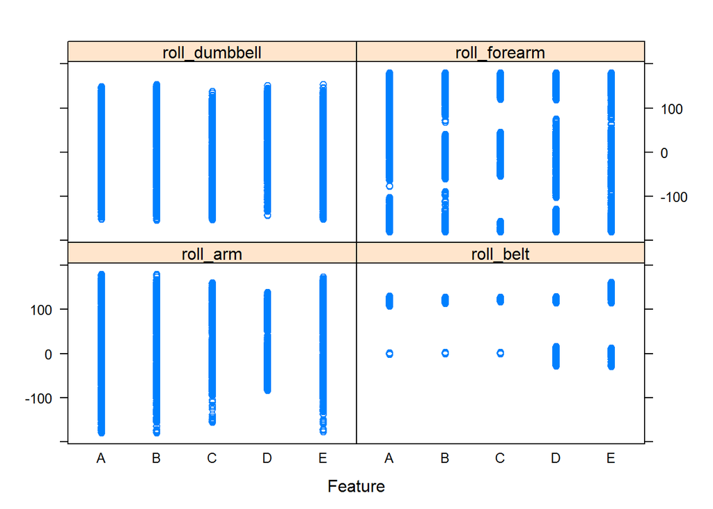

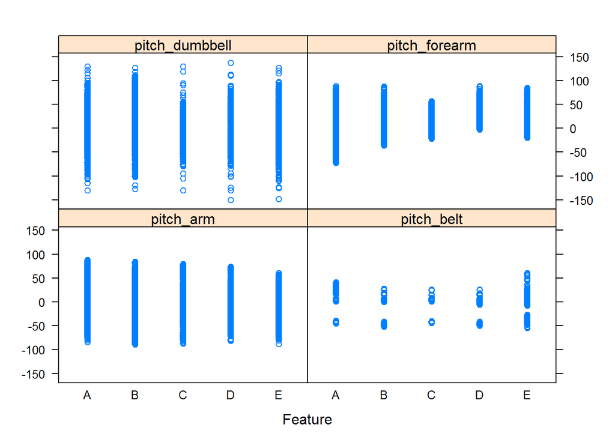

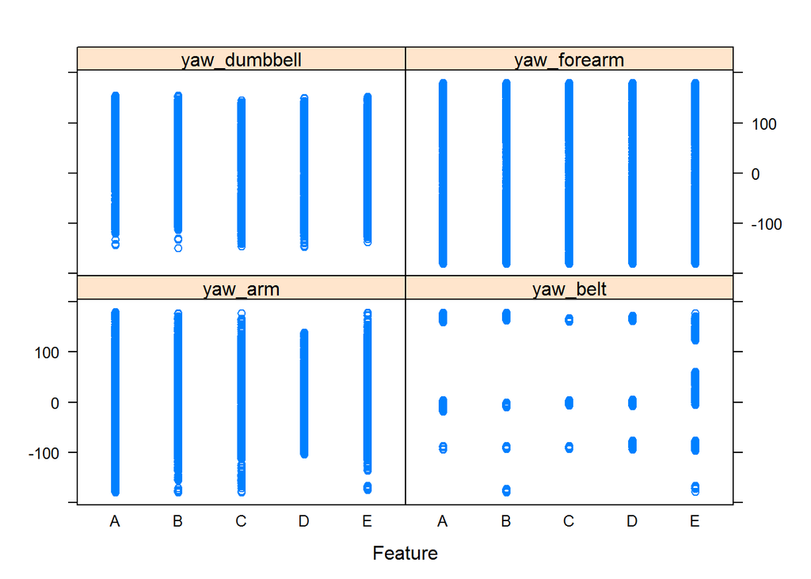

It doesn’t look like these features will need to be transformed.

## Modeling Building

### Decision Tree

```r
set.seed(2468)
modFit <- train(classe ~ ., method="rpart", data=train_short)
pred.t <- predict(modFit, newdata=test_short)
confusionMatrix(pred.t, test_short$classe)
```

```
## Confusion Matrix and Statistics
##
##           Reference
## Prediction    A    B    C    D    E
##          A 1523  461  455  427  142
##          B   27  407   42  189  136
##          C  120  271  529  348  295
##          D    0    0    0    0    0
##          E    4    0    0    0  509
##
## Overall Statistics
##
##                Accuracy : 0.5043
##                  95% CI : (0.4915, 0.5172)
##     No Information Rate : 0.2845
##     P-Value [Acc > NIR] : < 2.2e-16
##
##                   Kappa : 0.3529
##  Mcnemar's Test P-Value : NA
##
## Statistics by Class:
##
##                      Class: A Class: B Class: C Class: D Class: E
## Sensitivity            0.9098  0.35733  0.51559   0.0000  0.47043
## Specificity            0.6474  0.91698  0.78720   1.0000  0.99917
## Pos Pred Value         0.5063  0.50811  0.33845      NaN  0.99220
## Neg Pred Value         0.9475  0.85602  0.88501   0.8362  0.89334
## Prevalence             0.2845  0.19354  0.17434   0.1638  0.18386
## Detection Rate         0.2588  0.06916  0.08989   0.0000  0.08649
## Detection Prevalence   0.5111  0.13611  0.26559   0.0000  0.08717
## Balanced Accuracy      0.7786  0.63716  0.65140   0.5000  0.73480
```

### Random Forests

```r
set.seed(3579)
modFit_rf <- randomForest(classe ~ ., method="rf", data=train_short)
pred.rf <- predict(modFit_rf, newdata=test_short)
confusionMatrix(pred.rf, test_short$classe)
```

```
## Confusion Matrix and Statistics
##
##           Reference
## Prediction    A    B    C    D    E
##          A 1674    5    0    0    0
##          B    0 1132    3    0    0
##          C    0    2 1022   14    0
##          D    0    0    1  949    0
##          E    0    0    0    1 1082
##
## Overall Statistics
##
##                Accuracy : 0.9956
##                  95% CI : (0.9935, 0.9971)
##     No Information Rate : 0.2845
##     P-Value [Acc > NIR] : < 2.2e-16
##
##                   Kappa : 0.9944
##  Mcnemar's Test P-Value : NA
##
## Statistics by Class:
##
##                      Class: A Class: B Class: C Class: D Class: E
## Sensitivity            1.0000   0.9939   0.9961   0.9844   1.0000
## Specificity            0.9988   0.9994   0.9967   0.9998   0.9998
## Pos Pred Value         0.9970   0.9974   0.9846   0.9989   0.9991
## Neg Pred Value         1.0000   0.9985   0.9992   0.9970   1.0000
## Prevalence             0.2845   0.1935   0.1743   0.1638   0.1839
## Detection Rate         0.2845   0.1924   0.1737   0.1613   0.1839
## Detection Prevalence   0.2853   0.1929   0.1764   0.1614   0.1840
## Balanced Accuracy      0.9994   0.9966   0.9964   0.9921   0.9999
```

The prediction accuracy and kappa is great for this approach – over 99%. Almost every prediction was correct in the test set.

### Model Based Prediction

```r
set.seed(5432)
modFit_lda <- train(classe ~ ., method="lda", data=train_short)
pred.lda <- predict(modFit_lda, newdata=test_short)
confusionMatrix(pred.lda, test_short$classe)
```

```
## Confusion Matrix and Statistics
##
##           Reference
## Prediction    A    B    C    D    E
##          A 1393  161  116   66   42
##          B   27  724   95   33  166
##          C  131  142  652  119   89
##          D  117   37  132  707  109
##          E    6   75   31   39  676
##
## Overall Statistics
##
##                Accuracy : 0.7055
##                  95% CI : (0.6937, 0.7171)
##     No Information Rate : 0.2845
##     P-Value [Acc > NIR] : < 2.2e-16
##
##                   Kappa : 0.6271
##  Mcnemar's Test P-Value : < 2.2e-16
##
## Statistics by Class:
##
##                      Class: A Class: B Class: C Class: D Class: E
## Sensitivity            0.8321   0.6356   0.6355   0.7334   0.6248
## Specificity            0.9086   0.9324   0.9010   0.9197   0.9686
## Pos Pred Value         0.7835   0.6928   0.5755   0.6416   0.8174
## Neg Pred Value         0.9316   0.9143   0.9213   0.9463   0.9197
## Prevalence             0.2845   0.1935   0.1743   0.1638   0.1839
## Detection Rate         0.2367   0.1230   0.1108   0.1201   0.1149
## Detection Prevalence   0.3021   0.1776   0.1925   0.1873   0.1405
## Balanced Accuracy      0.8704   0.7840   0.7682   0.8266   0.7967
```

This approach was better than the decision tree (.70 accuracy, .62 kappa) but not as good as the random forests.

### Model Selection and Out of Sample Error

Since the random forest model was so good, ensemble models are not needed.

### Variable Importance from Random Forest Model

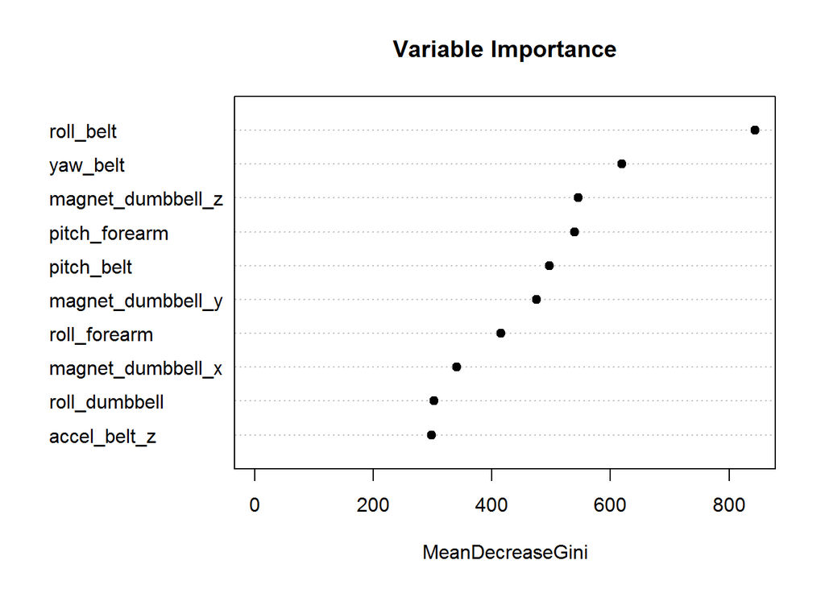

```r
varImpPlot(modFit_rf, pch=19, n.var = 10, sort = T, main = "Variable Importance")
```